# R Notebook sandbox: Playing with K-means

# 1 Top of the world

# 2 Good Resources as we move forward into Multivariate Analysis

This resource (channel) https://www.youtube.com/channel/UCtYLUTtgS3k1Fg4y5tAhLbw seems to be informative and instructive for those that need additional explanations on these topics, or key statistical methods/terminologies.

- **HCLUST** https://www.youtube.com/watch?v=7xHsRkOdVwo
- **K-means** https://www.youtube.com/watch?v=4b5d3muPQmA
- **PCA** https://www.youtube.com/watch?v=_UVHneBUBW0
- **Flipping Coins / Measuring Person’s Heights** https://www.youtube.com/watch?v=5Z9OIYA8He8
- **eigenvectors** https://www.youtube.com/watch?v=PFDu9oVAE-g

# 3 K-means

We are now going to apply distance to aggregate multivariate data. Recall that typically we refer to a data frame based on its rows and columns. Generally, the rows represent observations and the columns represent features.

As we try to aggregate data, we need to ask: are we aggregating the rows or the columns? Why? So let’s look at an example.

```r
library(humanVerseWSU);
# You need R tools for this to work:  https://cran.r-project.org/bin/windows/Rtools/
# You may want to see if you have the latest version...
# library(devtools);
# detach(package:humanVerseWSU);
# install_github("MonteShaffer/humanVerseWSU/humanVerseWSU");
# Choose (3) None to minimize headaches ....
# library(humanVerseWSU);


path.to.week7 = "C:/Users/Nic Trout/Documents/C/WSU_STATS419_FALL2020/WEEK-07/";

path.graphics = paste0(path.to.week7,"graphics/");

createDirRecursive(path.graphics);



example.datasets.path = "C:/Users/Nic Trout/Documents/C/WSU_STATS419_FALL2020/WEEK-07/";




protein.file = paste0(example.datasets.path,"protein.txt");
protein = read.table(protein.file,sep = "\t", header = TRUE);

cols = colnames(protein);
rows = protein$Country;

protein
```

| Country | RedMeat | WhiteMeat | Eggs | Milk | Fish | Cereals | Starch | Nuts | Fr.Veg |
| --- | --- | --- | --- | --- | --- | --- | --- | --- | --- |
| Albania | 10.1 | 1.4 | 0.5 | 8.9 | 0.2 | 42.3 | 0.6 | 5.5 | 1.7 |
| Austria | 8.9 | 14.0 | 4.3 | 19.9 | 2.1 | 28.0 | 3.6 | 1.3 | 4.3 |
| Belgium | 13.5 | 9.3 | 4.1 | 17.5 | 4.5 | 26.6 | 5.7 | 2.1 | 4.0 |
| Bulgaria | 7.8 | 6.0 | 1.6 | 8.3 | 1.2 | 56.7 | 1.1 | 3.7 | 4.2 |
| Czechoslovakia | 9.7 | 11.4 | 2.8 | 12.5 | 2.0 | 34.3 | 5.0 | 1.1 | 4.0 |
| Denmark | 10.6 | 10.8 | 3.7 | 25.0 | 9.9 | 21.9 | 4.8 | 0.7 | 2.4 |
| E Germany | 8.4 | 11.6 | 3.7 | 11.1 | 5.4 | 24.6 | 6.5 | 0.8 | 3.6 |
| Finland | 9.5 | 4.9 | 2.7 | 33.7 | 5.8 | 26.3 | 5.1 | 1.0 | 1.4 |
| France | 18.0 | 9.9 | 3.3 | 19.5 | 5.7 | 28.1 | 4.8 | 2.4 | 6.5 |
| Greece | 10.2 | 3.0 | 2.8 | 17.6 | 5.9 | 41.7 | 2.2 | 7.8 | 6.5 |

[output cut: 15 more lines]

```r
df = removeColumnsFromDataFrame(protein,"Country");
df.t = transposeMatrix(df);
colnames(df.t) = rows;

protein.t = as.data.frame(df.t);
protein.t;
```

|  | Albania | Austria | Belgium | Bulgaria | Czechoslovakia | Denmark | E Germany | Finland | France | Greece | Hungary | Ireland | Italy | Netherlands | Norway | Poland | Portugal | Romania | Spain | Sweden | Switzerland | UK | USSR | W Germany | Yugoslavia |
| --- | --- | --- | --- | --- | --- | --- | --- | --- | --- | --- | --- | --- | --- | --- | --- | --- | --- | --- | --- | --- | --- | --- | --- | --- | --- |
| RedMeat | 10.1 | 8.9 | 13.5 | 7.8 | 9.7 | 10.6 | 8.4 | 9.5 | 18.0 | 10.2 | 5.3 | 13.9 | 9.0 | 9.5 | 9.4 | 6.9 | 6.2 | 6.2 | 7.1 | 9.9 | 13.1 | 17.4 | 9.3 | 11.4 | 4.4 |
| WhiteMeat | 1.4 | 14.0 | 9.3 | 6.0 | 11.4 | 10.8 | 11.6 | 4.9 | 9.9 | 3.0 | 12.4 | 10.0 | 5.1 | 13.6 | 4.7 | 10.2 | 3.7 | 6.3 | 3.4 | 7.8 | 10.1 | 5.7 | 4.6 | 12.5 | 5.0 |
| Eggs | 0.5 | 4.3 | 4.1 | 1.6 | 2.8 | 3.7 | 3.7 | 2.7 | 3.3 | 2.8 | 2.9 | 4.7 | 2.9 | 3.6 | 2.7 | 2.7 | 1.1 | 1.5 | 3.1 | 3.5 | 3.1 | 4.7 | 2.1 | 4.1 | 1.2 |
| Milk | 8.9 | 19.9 | 17.5 | 8.3 | 12.5 | 25.0 | 11.1 | 33.7 | 19.5 | 17.6 | 9.7 | 25.8 | 13.7 | 23.4 | 23.3 | 19.3 | 4.9 | 11.1 | 8.6 | 24.7 | 23.8 | 20.6 | 16.6 | 18.8 | 9.5 |
| Fish | 0.2 | 2.1 | 4.5 | 1.2 | 2.0 | 9.9 | 5.4 | 5.8 | 5.7 | 5.9 | 0.3 | 2.2 | 3.4 | 2.5 | 9.7 | 3.0 | 14.2 | 1.0 | 7.0 | 7.5 | 2.3 | 4.3 | 3.0 | 3.4 | 0.6 |
| Cereals | 42.3 | 28.0 | 26.6 | 56.7 | 34.3 | 21.9 | 24.6 | 26.3 | 28.1 | 41.7 | 40.1 | 24.0 | 36.8 | 22.4 | 23.0 | 36.1 | 27.0 | 49.6 | 29.2 | 19.5 | 25.6 | 24.3 | 43.6 | 18.6 | 55.9 |
| Starch | 0.6 | 3.6 | 5.7 | 1.1 | 5.0 | 4.8 | 6.5 | 5.1 | 4.8 | 2.2 | 4.0 | 6.2 | 2.1 | 4.2 | 4.6 | 5.9 | 5.9 | 3.1 | 5.7 | 3.7 | 2.8 | 4.7 | 6.4 | 5.2 | 3.0 |
| Nuts | 5.5 | 1.3 | 2.1 | 3.7 | 1.1 | 0.7 | 0.8 | 1.0 | 2.4 | 7.8 | 5.4 | 1.6 | 4.3 | 1.8 | 1.6 | 2.0 | 4.7 | 5.3 | 5.9 | 1.4 | 2.4 | 3.4 | 3.4 | 1.5 | 5.7 |
| Fr.Veg | 1.7 | 4.3 | 4.0 | 4.2 | 4.0 | 2.4 | 3.6 | 1.4 | 6.5 | 6.5 | 4.2 | 2.9 | 6.7 | 3.7 | 2.7 | 6.6 | 7.9 | 2.8 | 7.2 | 2.0 | 4.9 | 3.3 | 2.9 | 3.8 | 3.2 |

Previously, I asked if you should scale the data: `Xs = scale(X);` … the general rule is YES. But in context of this data, it will not matter too much as the data is all measured in “grams of protein intake” … If however, the units of the data were very different (consider: height, weight, and temperature in degrees Fahrenheit), it will very much matter.

## 3.1 Play with K-means

K-means uses the distances between the data to group the data into “k” centroid-based clusters.

Type `?kmeans` and notice centers is the number for `k`. We could pass in a vector of cluster centers, it length would still tell us the `k`.

We normally think about distance in 2-D (x,y) or 3-D (x,y,z). The latitude/longitude is a simple 2-D flattening approach. In mathematics, we can go beyond 3-D (read the book “Flatland” if you want to think more about n-D).

So when we talk about distance, we can compute a Euclidean distance or any other form based on more than 3-D; that is; n-D. And that is what happens behind the scenes in Multivariate Analysis.

### 3.1.1 K-means (junior varsity)

```r
X = removeColumnsFromDataFrame(protein,"Country");
rownames(X) = protein$Country;
X
```

|  | RedMeat | WhiteMeat | Eggs | Milk | Fish | Cereals | Starch | Nuts | Fr.Veg |
| --- | --- | --- | --- | --- | --- | --- | --- | --- | --- |
| Albania | 10.1 | 1.4 | 0.5 | 8.9 | 0.2 | 42.3 | 0.6 | 5.5 | 1.7 |
| Austria | 8.9 | 14.0 | 4.3 | 19.9 | 2.1 | 28.0 | 3.6 | 1.3 | 4.3 |
| Belgium | 13.5 | 9.3 | 4.1 | 17.5 | 4.5 | 26.6 | 5.7 | 2.1 | 4.0 |
| Bulgaria | 7.8 | 6.0 | 1.6 | 8.3 | 1.2 | 56.7 | 1.1 | 3.7 | 4.2 |
| Czechoslovakia | 9.7 | 11.4 | 2.8 | 12.5 | 2.0 | 34.3 | 5.0 | 1.1 | 4.0 |
| Denmark | 10.6 | 10.8 | 3.7 | 25.0 | 9.9 | 21.9 | 4.8 | 0.7 | 2.4 |
| E Germany | 8.4 | 11.6 | 3.7 | 11.1 | 5.4 | 24.6 | 6.5 | 0.8 | 3.6 |
| Finland | 9.5 | 4.9 | 2.7 | 33.7 | 5.8 | 26.3 | 5.1 | 1.0 | 1.4 |
| France | 18.0 | 9.9 | 3.3 | 19.5 | 5.7 | 28.1 | 4.8 | 2.4 | 6.5 |
| Greece | 10.2 | 3.0 | 2.8 | 17.6 | 5.9 | 41.7 | 2.2 | 7.8 | 6.5 |

[output cut: 15 more lines]

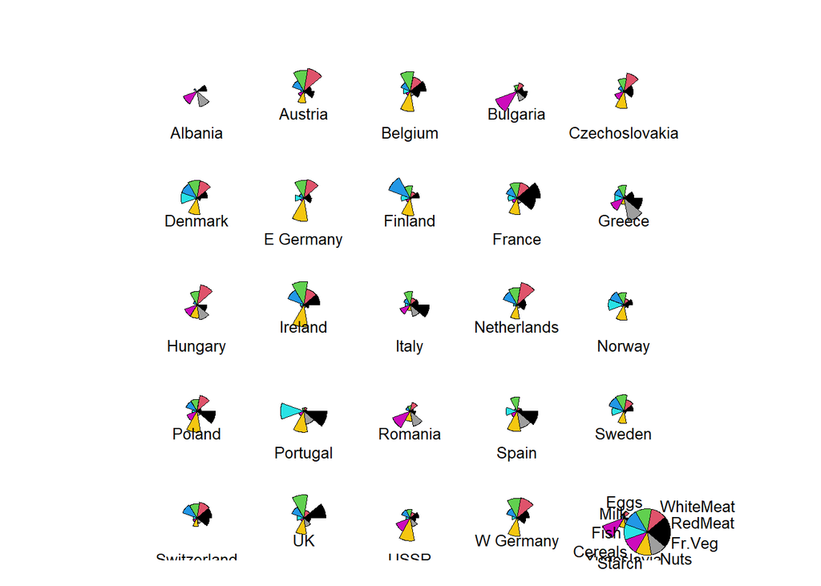

```r
# first a descriptive plot by country
stars(X, len = 0.5, key.loc=c(12,2), draw.segments = TRUE);
```

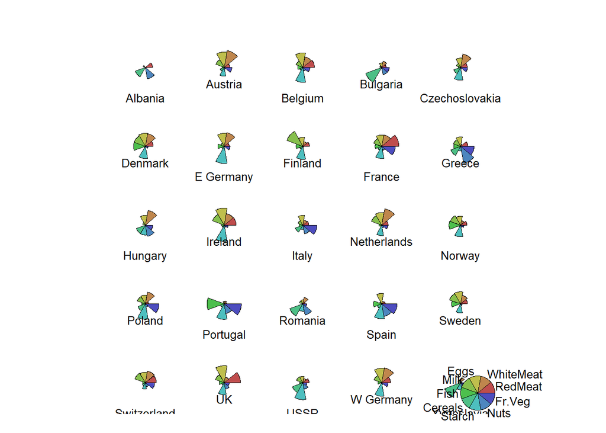

```r
# stars need a better palette
palette(rainbow(12, s = 0.6, v = 0.75));
# redraw
stars(X, len = 0.5, key.loc=c(12,2), draw.segments = TRUE);
```

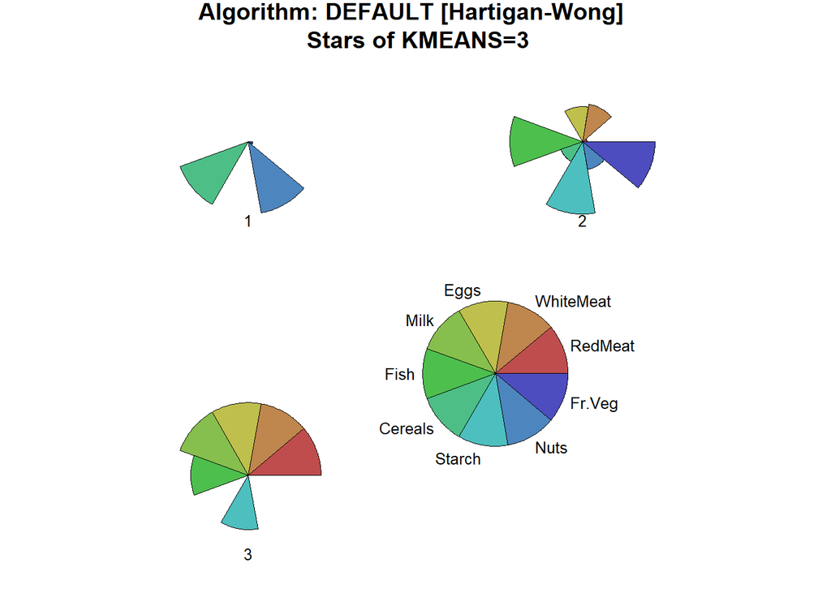

```r
# for the faint of heart ...
X.kmeans = kmeans(X, 3);  # default algorithm
stars(X.kmeans$centers, len = 0.5, key.loc = c(4, 3),
        main = "Algorithm: DEFAULT [Hartigan-Wong] \n Stars of KMEANS=3", draw.segments = TRUE);
```

```r
print(X.kmeans);
```

```
## K-means clustering with 3 clusters of sizes 7, 6, 12
##
## Cluster means:
##     RedMeat WhiteMeat     Eggs     Milk     Fish  Cereals   Starch     Nuts
## 1  7.614286  5.528571 1.800000 11.67143 1.742857 47.12857 2.914286 5.257143
## 2  7.883333  7.566667 2.716667 11.68333 5.833333 31.33333 5.183333 3.133333
## 3 12.091667  9.441667 3.708333 23.00000 4.991667 24.02500 4.616667 1.766667
##     Fr.Veg
## 1 3.642857
## 2 6.000000
## 3 3.491667
##
## Clustering vector:
##        Albania        Austria        Belgium       Bulgaria Czechoslovakia
##              1              3              3              1              2
##        Denmark      E Germany        Finland         France         Greece
##              3              2              3              3              1
##        Hungary        Ireland          Italy    Netherlands         Norway
##              1              3              2              3              3
##         Poland       Portugal        Romania          Spain         Sweden
##              2              2              1              2              3
##    Switzerland             UK           USSR      W Germany     Yugoslavia
##              3              3              1              3              1
##
## Within cluster sum of squares by cluster:
## [1] 561.8714 488.7267 656.4517
##  (between_SS / total_SS =  67.4 %)
##
## Available components:
##
## [1] "cluster"      "centers"      "totss"        "withinss"     "tot.withinss"
## [6] "betweenss"    "size"         "iter"         "ifault"
```

```r
    membership = as.data.frame( matrix( X.kmeans$cluster, ncol=1)) ;

    rownames(membership) = protein$Country;

    membership;
```

|  | V1 |
| --- | --- |
| Albania | 1 |
| Austria | 3 |
| Belgium | 3 |
| Bulgaria | 1 |
| Czechoslovakia | 2 |
| Denmark | 3 |
| E Germany | 2 |
| Finland | 3 |
| France | 3 |
| Greece | 1 |

[output cut: 15 more lines]

```r
    print( table(membership) ) ;
```

```
## membership
##  1  2  3
##  7  6 12
```

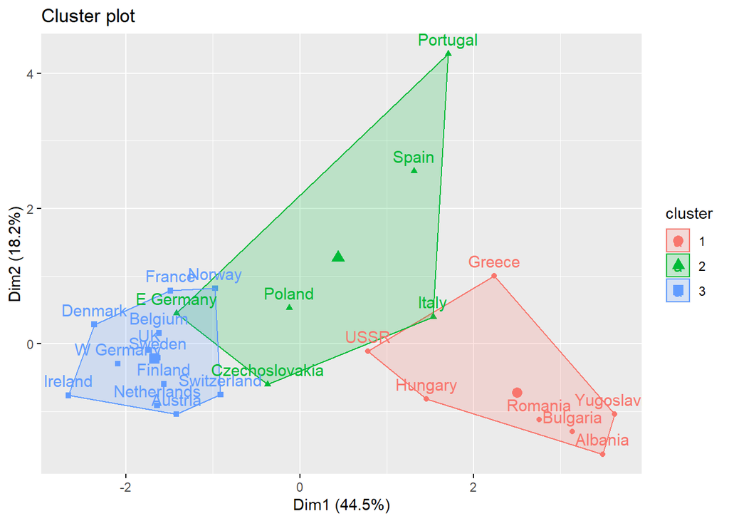

```r
########################################

# we can't easily plot all of the dimensions, since it is more than 2-D or 3-D ... so we can "cheat" and apply some PCA techniques to data-reduce to two dimensions ...

library(factoextra);   # install.packages("factoextra", dependencies=TRUE);

# this approach uses ggplot2 (not plot)
library(ggplot2);   # install.packages("ggplot2", dependencies=TRUE);
fviz_cluster(X.kmeans,data=X);
```

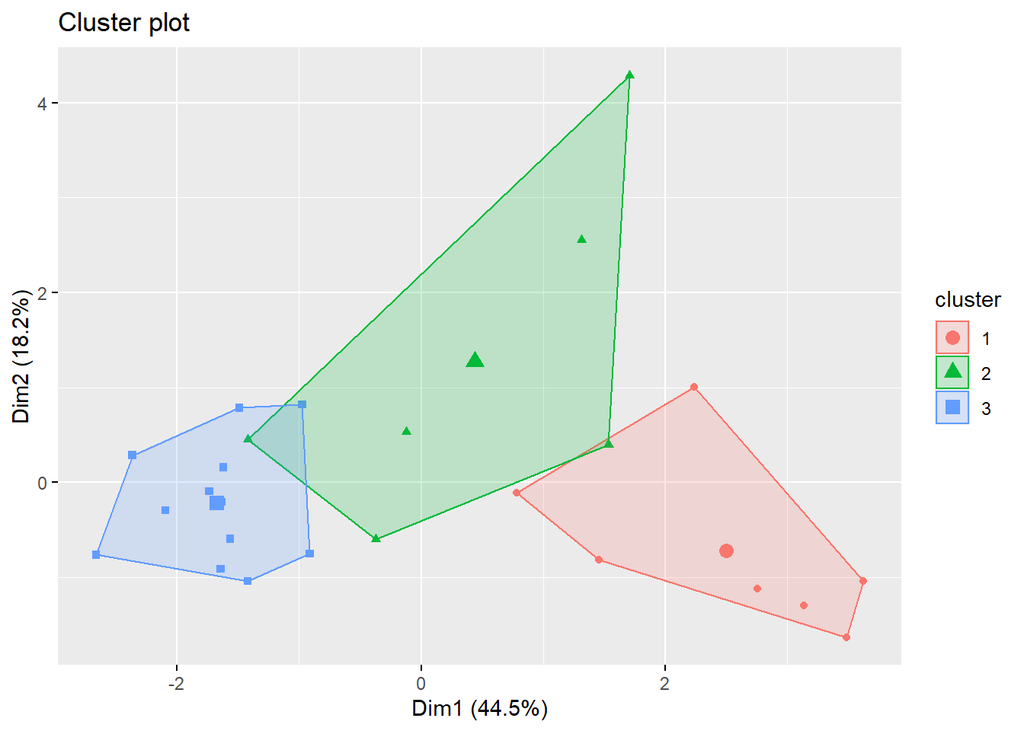

```r
fviz_cluster(X.kmeans, data=X, geom="point");
```

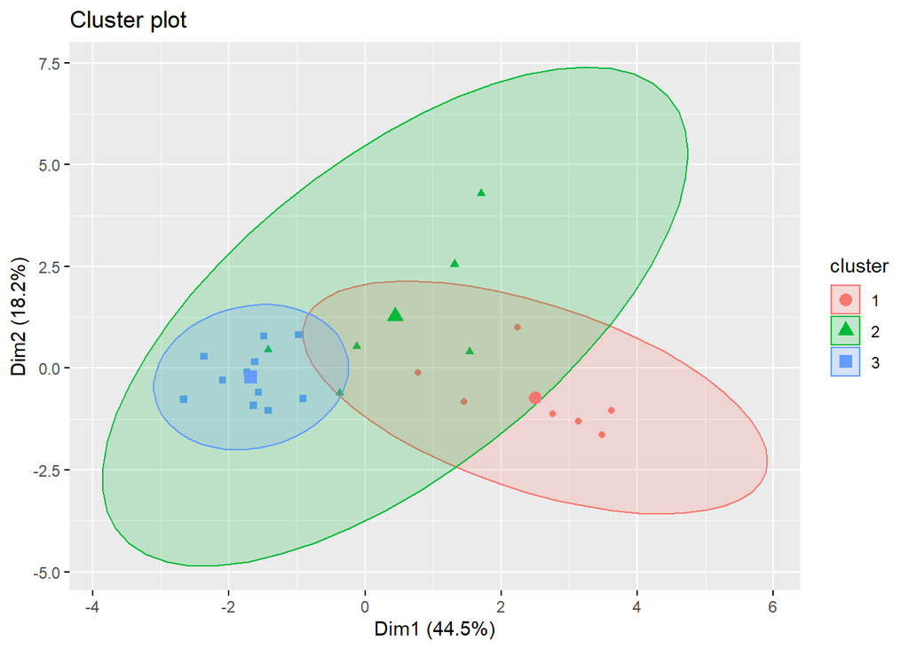

```r
# assumes the cluster is normal?
fviz_cluster(X.kmeans, data=X, geom="point", ellipse.type = "norm");
```

```r
# try ?fviz_cluster
```

### 3.1.2 K-means (varsity)

```r
# now for a "FOR LOOP ON STEROIDS"
# a variadic approach ...

path.loop.graphics = paste0(path.graphics,"forloops/");

createDirRecursive(path.loop.graphics);

print(path.loop.graphics);
```

```
## [1] "C:/Users/Nic Trout/Documents/C/WSU_STATS419_FALL2020/WEEK-07/graphics/forloops/"
```

```
## [1] "algorithm: Hartigan-Wong ==> 2"
```

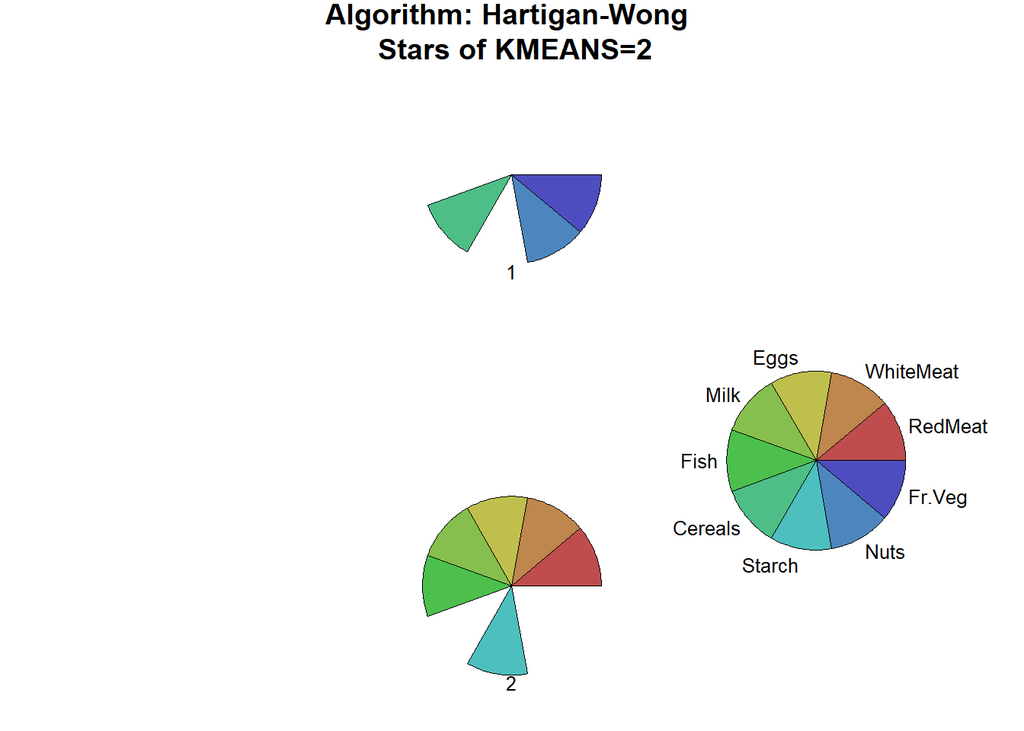

```
##
##  1  2
## 12 13
## [1] "fviz_cluster is not rendering inside of for loop"
## [1] "algorithm: Hartigan-Wong ===> 3"
```

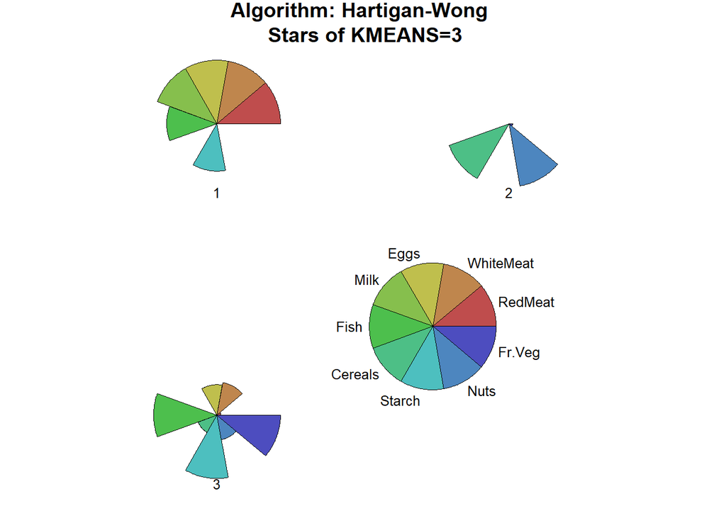

```
##
##  1  2  3
## 12  7  6
## [1] "fviz_cluster is not rendering inside of for loop"
## [1] "algorithm: Hartigan-Wong ====> 4"
```

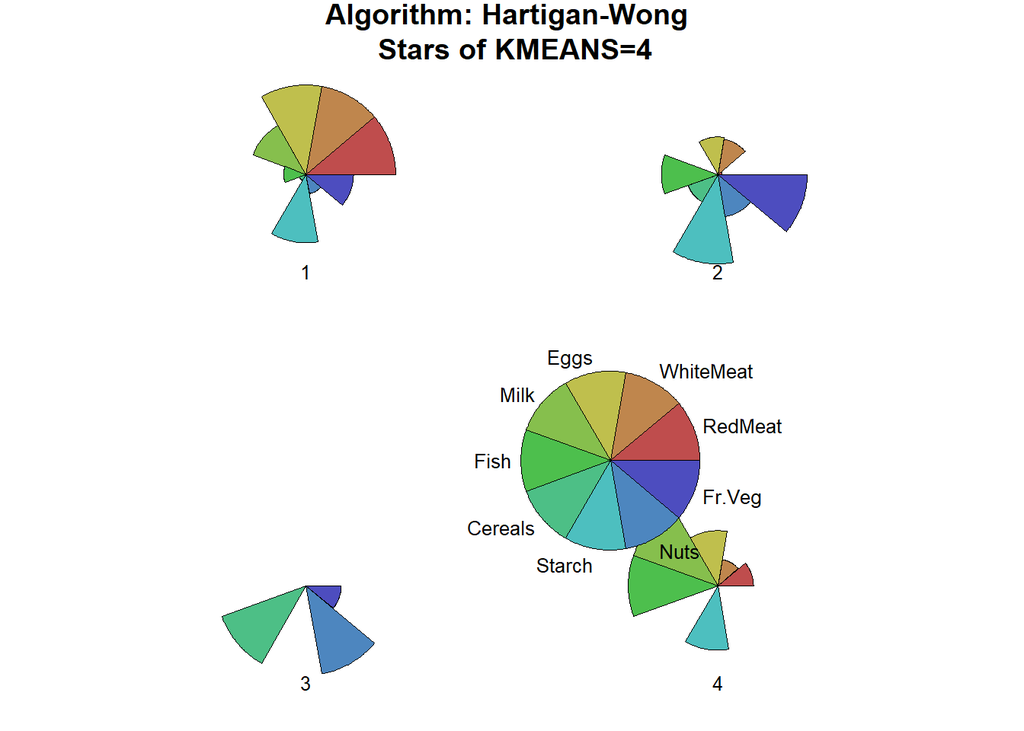

```
##
## 1 2 3 4
## 8 6 7 4
## [1] "fviz_cluster is not rendering inside of for loop"
## [1] "algorithm: Hartigan-Wong =====> 5"
```

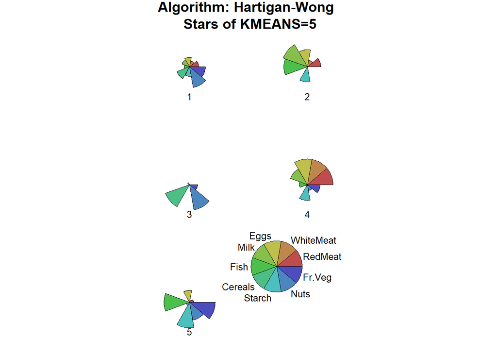

```
##
## 1 2 3 4 5
## 7 4 3 8 3
## [1] "fviz_cluster is not rendering inside of for loop"
## [1] "algorithm: Hartigan-Wong ======> 6"
```

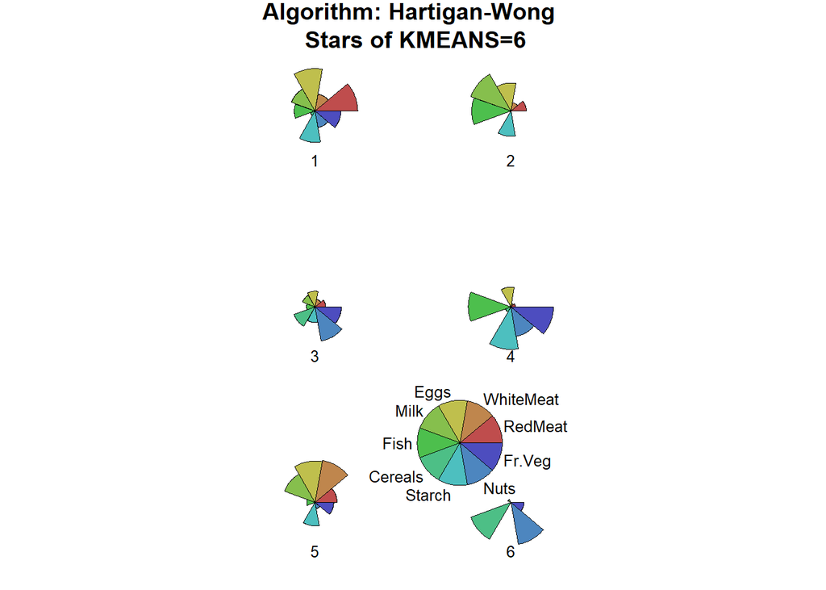

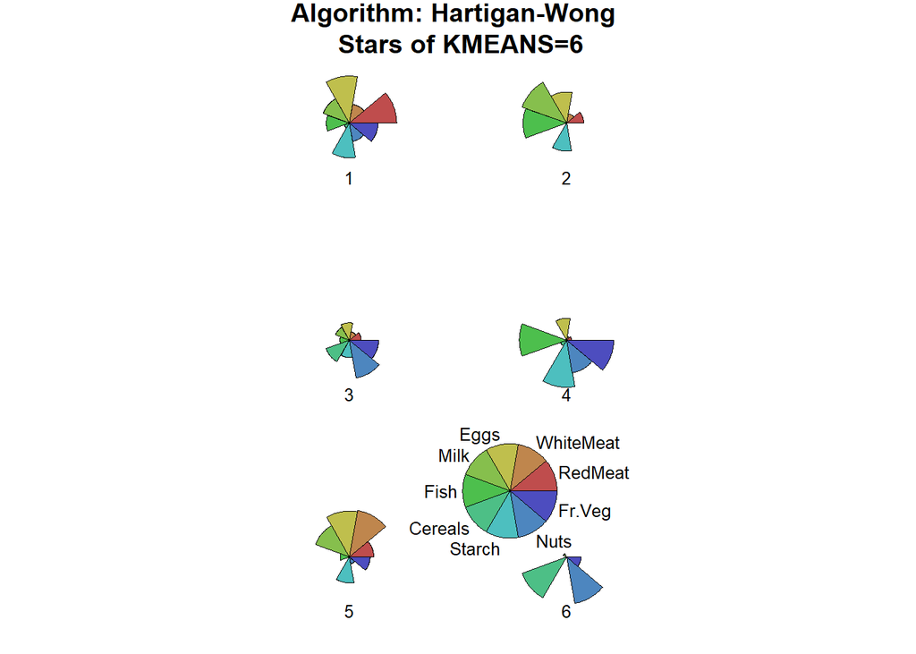

```
##
## 1 2 3 4 5 6
## 3 4 7 3 5 3
## [1] "fviz_cluster is not rendering inside of for loop"
```

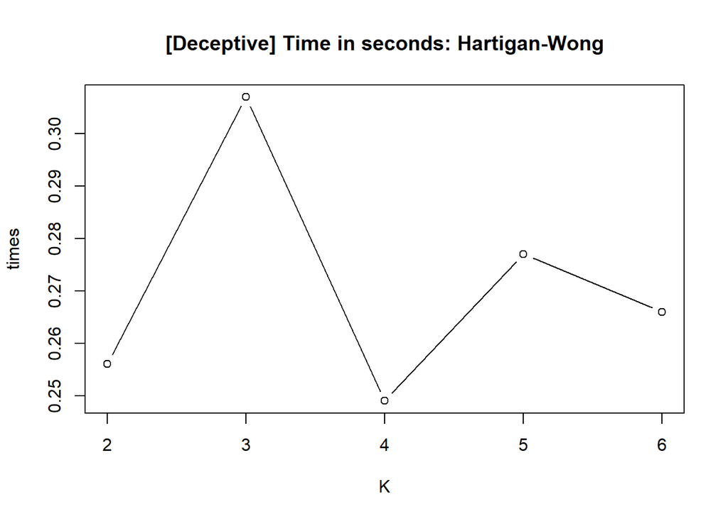

[figure not shown]

```
## [1] "algorithm: Lloyd ==> 2"
```

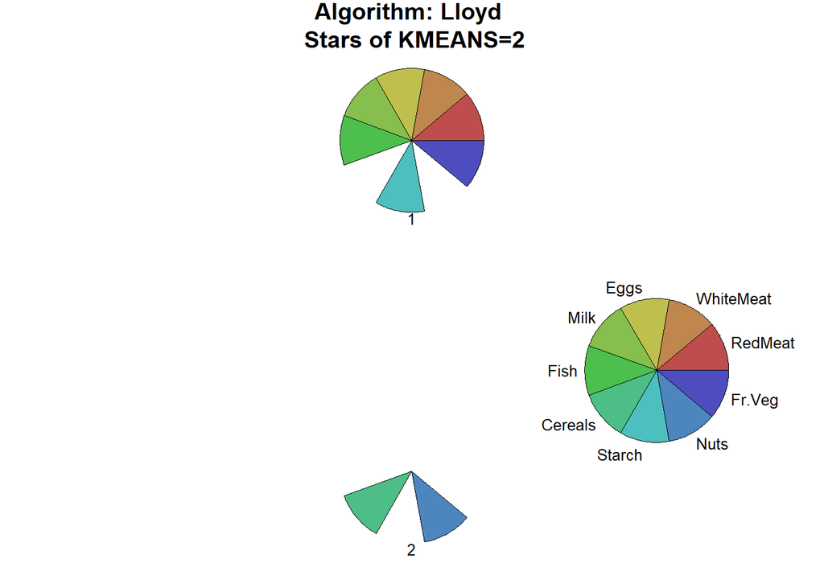

```
##
##  1  2
## 17  8
## [1] "fviz_cluster is not rendering inside of for loop"
## [1] "algorithm: Lloyd ===> 3"
```

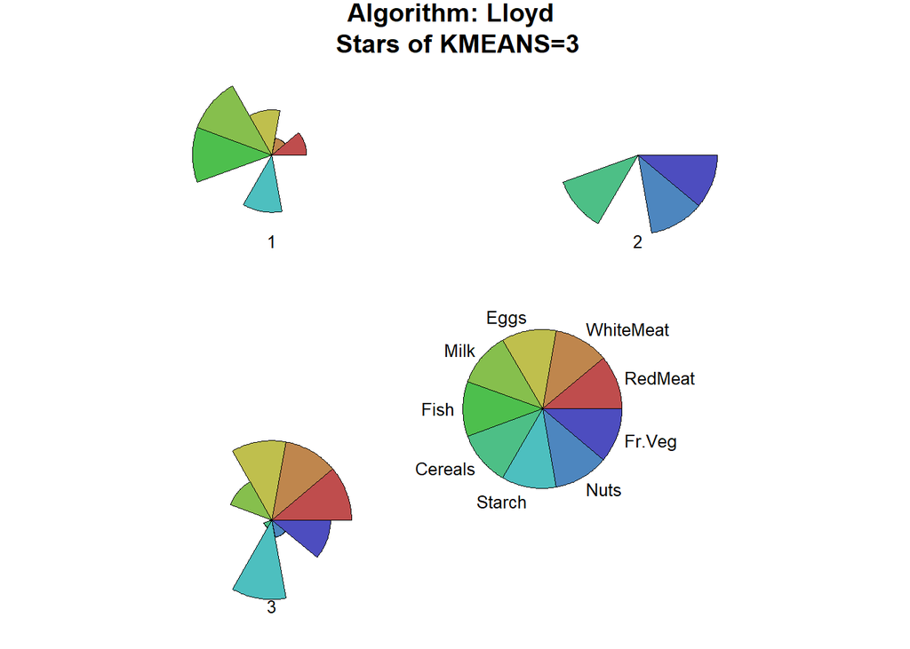

```
##
##  1  2  3
##  4 12  9
## [1] "fviz_cluster is not rendering inside of for loop"
## [1] "algorithm: Lloyd ====> 4"
```

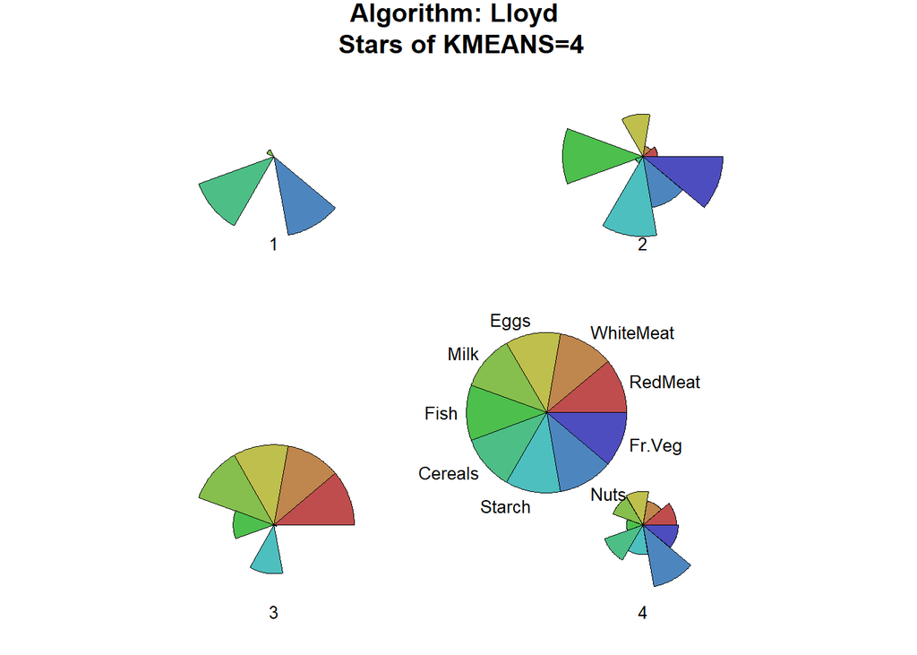

```
##
##  1  2  3  4
##  3  3 12  7
## [1] "fviz_cluster is not rendering inside of for loop"
## [1] "algorithm: Lloyd =====> 5"
```

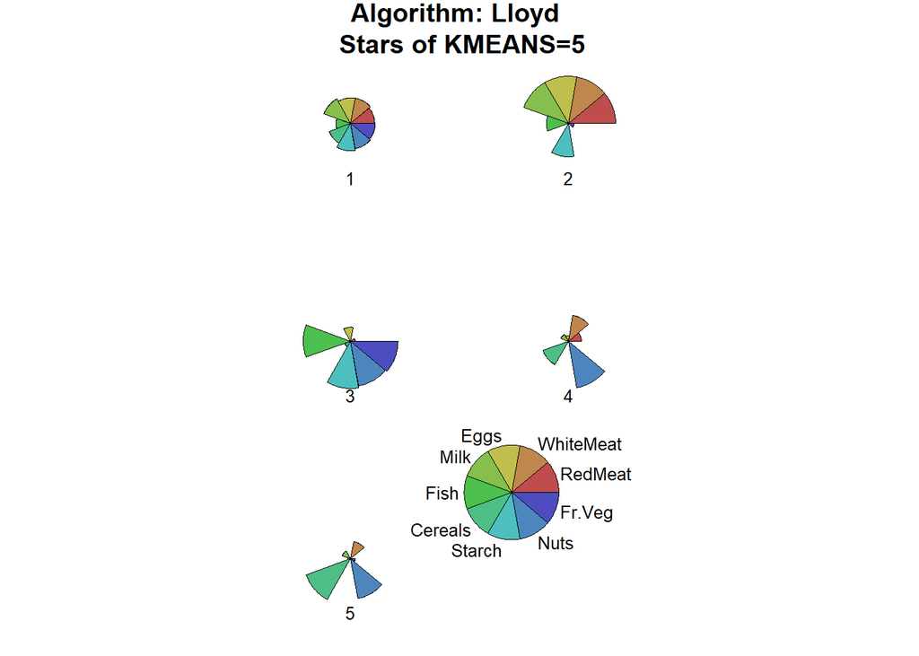

```
##
##  1  2  3  4  5
##  5 13  2  2  3
## [1] "fviz_cluster is not rendering inside of for loop"
## [1] "algorithm: Lloyd ======> 6"
```

[20 more figures not shown]

```r
# maybe open this folder before you run this code ...

wss.png.list = c();

n.Countries = dim(X)[1];
n.Features = dim(X)[2];

K = 2:6;  # let's try these choices for our "k"
n.K = length(K);

algorithms = c("Hartigan-Wong", "Lloyd", "Forgy", "MacQueen");
n.A = length(algorithms);

# a nested for loop, order matters, I want to study each algorithm as I loop over the special K's

membership = as.data.frame(
                matrix(0, nrow=n.Countries, ncol=n.K*n.A) );
  rownames(membership) = protein$Country;

m.col.names = c(); # don't know these yet ...

j=0;
for(algorithm in algorithms)
  {
  wss = numeric(n.K); # total within-sum-of-squares
  times = numeric(n.K);
  i = 0;
  for(k in K)
    {
    print( paste0("algorithm: ", algorithm, " ",
           paste0(rep("=",times=k),collapse=""), "> ",k));
    j = 1 + j;
    i = 1 + i;
    time.start = Sys.time();
    # I am appending to kmeans some previous results, so:
      #X.kmeans = kmeans(X[,n.Features], k, algorithm=algorithm);
    X.kmeans = kmeans(X, k, algorithm=algorithm);
      # str(X.kmeans);

      # key.loc probably needs to be adjusted per kmeans instance ... once you have a final answer, for your final writeup, you would really take the time to make the graph look perfect ... we are in a sandbox ... the "legend or key" may cover up one of your results.


stars(X.kmeans$centers, len = 0.5, key.loc = c(4, 3),
            main = paste0("Algorithm: ", algorithm,
              " \n Stars of KMEANS=",k), draw.segments = TRUE);

    star.file = paste0(path.loop.graphics,"algo-", paste0(tolower(algorithm),collapse=""),"_k-",k,"_stars_.png");  # could also do PDF

################### writes image as png to file
png(star.file);
    stars(X.kmeans$centers, len = 0.5, key.loc = c(4, 3),
            main = paste0("Algorithm: ", algorithm,
              " \n Stars of KMEANS=",k), draw.segments = TRUE);
dev.off();
###################

################### writes image as pdf to file
pdf( gsub(".png",".pdf",star.file, fixed=TRUE) );
    stars(X.kmeans$centers, len = 0.5, key.loc = c(4, 3),
            main = paste0("Algorithm: ", algorithm,
              " \n Stars of KMEANS=",k), draw.segments = TRUE);
dev.off();
###################
# obviously, subfolders may help ... this is a demo ...

        stars(X.kmeans$centers, len = 0.5, key.loc = c(4, 3),
            main = paste0("Algorithm: ", algorithm,
              " \n Stars of KMEANS=",k), draw.segments = TRUE);


    # map of clusters back to countries
    my.key = paste0(algorithm,".",k);
    m.col.names = c(m.col.names, my.key);

    membership[,j] = X.kmeans$cluster;

    print( table(X.kmeans$cluster) ) ;
    #plot(X, col=X.kmeans$cluster);
    #points(X.kmeans$centers, col = 1:2, pch = 8, cex = 2);

    time.end = Sys.time();
    elapse = sprintf("%.3f",
                as.numeric(time.end) - as.numeric(time.start));

# don't include this step in "timings" ... slows things down...
# rendering?

pca.clust.file = gsub("_stars_","_clusters_",star.file, fixed=TRUE);



################### writes image as png to file
png(pca.clust.file);
    fviz_cluster(X.kmeans, data=X,
                geom="point", ellipse.type = "norm");
dev.off();
###################

################### writes image as pdf to file
pdf( gsub(".png",".pdf",pca.clust.file, fixed=TRUE) );
    fviz_cluster(X.kmeans, data=X,
                geom="point", ellipse.type = "norm");
dev.off();
###################

print("fviz_cluster is not rendering inside of for loop");
fviz_cluster(X.kmeans, data=X,
                geom="point", ellipse.type = "norm");

    wss[i] = X.kmeans$tot.withinss;
    times[i] = elapse;
    }
  #print(times);
  #print(wss);
  base::plot(K,times, main=paste0("[Deceptive] Time in seconds: ",algorithm), type="b"); # deceptive ... you need to run the code once, look at the ranges then rerun with valid ranges ...
  # if you want to compare graphs visually, they should have the same axes.
  # A good graph has a title, a xlab, a ylab
  # Final writeup should have a nice caption for each image ...

  base::plot(K,times, ylim=c(0, 0.1), main=paste0("Time in seconds: ",algorithm), type="b");

  wss.file = paste0(path.graphics,"algo-", paste0(tolower(algorithm),collapse=""),"_k-",k,"_wss_.png"); # this is one folder up ...

  wss.png.list = c(wss.png.list,wss.file);
################### writes image as png to file
png(wss.file);
    base::plot(K,wss, ylim=c(0,3000), main=paste0("Total WSS: ",algorithm), type="b");
dev.off();
###################

################### writes image as pdf to file
pdf( gsub(".png",".pdf",wss.file, fixed=TRUE) );
    base::plot(K,wss, ylim=c(0,3000), main=paste0("Total WSS: ",algorithm), type="b");
dev.off();
###################

  # knitr will probably automate this process for us, more to follow: <https://www.r-bloggers.com/2014/01/fast-track-publishing-using-knitr-exporting-images-for-sharing-and-press-part-iii/>

  # want to learn more about plot:  <https://statisticsglobe.com/plot-in-r-example>


  }
```

```r
colnames(membership) = m.col.names;
membership;
```

|  | Hartigan-Wong.2 | Hartigan-Wong.3 | Hartigan-Wong.4 | Hartigan-Wong.5 | Hartigan-Wong.6 | Lloyd.2 | Lloyd.3 | Lloyd.4 | Lloyd.5 | Lloyd.6 | Forgy.2 | Forgy.3 | Forgy.4 | Forgy.5 | Forgy.6 | MacQueen.2 | MacQueen.3 | MacQueen.4 | MacQueen.5 | MacQueen.6 |
| --- | --- | --- | --- | --- | --- | --- | --- | --- | --- | --- | --- | --- | --- | --- | --- | --- | --- | --- | --- | --- |
| Albania | 1 | 2 | 3 | 1 | 3 | 2 | 2 | 4 | 4 | 6 | 1 | 1 | 4 | 3 | 1 | 2 | 1 | 1 | 3 | 1 |
| Austria | 2 | 1 | 1 | 4 | 5 | 1 | 3 | 3 | 2 | 5 | 2 | 3 | 2 | 5 | 2 | 1 | 2 | 2 | 5 | 2 |
| Belgium | 2 | 1 | 1 | 4 | 1 | 1 | 3 | 3 | 2 | 2 | 2 | 3 | 2 | 1 | 2 | 1 | 2 | 2 | 5 | 4 |
| Bulgaria | 1 | 2 | 3 | 3 | 6 | 2 | 2 | 1 | 5 | 1 | 1 | 1 | 4 | 4 | 4 | 2 | 3 | 1 | 2 | 1 |
| Czechoslovakia | 1 | 3 | 2 | 1 | 3 | 1 | 2 | 4 | 1 | 3 | 1 | 2 | 4 | 5 | 3 | 2 | 1 | 2 | 3 | 1 |
| Denmark | 2 | 1 | 4 | 2 | 2 | 1 | 1 | 3 | 2 | 2 | 2 | 3 | 1 | 1 | 5 | 1 | 2 | 4 | 4 | 6 |
| E Germany | 2 | 3 | 2 | 5 | 4 | 1 | 3 | 2 | 2 | 3 | 2 | 2 | 2 | 5 | 2 | 1 | 2 | 2 | 1 | 3 |
| Finland | 2 | 1 | 4 | 2 | 2 | 1 | 1 | 3 | 2 | 2 | 2 | 3 | 3 | 1 | 6 | 1 | 2 | 4 | 4 | 5 |
| France | 2 | 1 | 1 | 4 | 1 | 1 | 3 | 3 | 2 | 2 | 2 | 3 | 2 | 1 | 2 | 1 | 2 | 2 | 5 | 4 |
| Greece | 1 | 2 | 3 | 1 | 3 | 2 | 2 | 4 | 1 | 4 | 1 | 1 | 4 | 3 | 1 | 2 | 1 | 1 | 3 | 1 |

[output cut: 15 more lines]

```r
# rendering?  ... BUGGY ...
print("fviz_cluster renders outside of for loop");
```

```
## [1] "fviz_cluster renders outside of for loop"
```

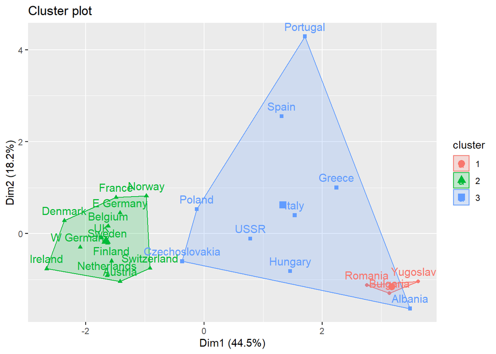

```r
k = 3; # my final answer?
X.kmeans = kmeans(X, k);
fviz_cluster(X.kmeans, data=X);
```

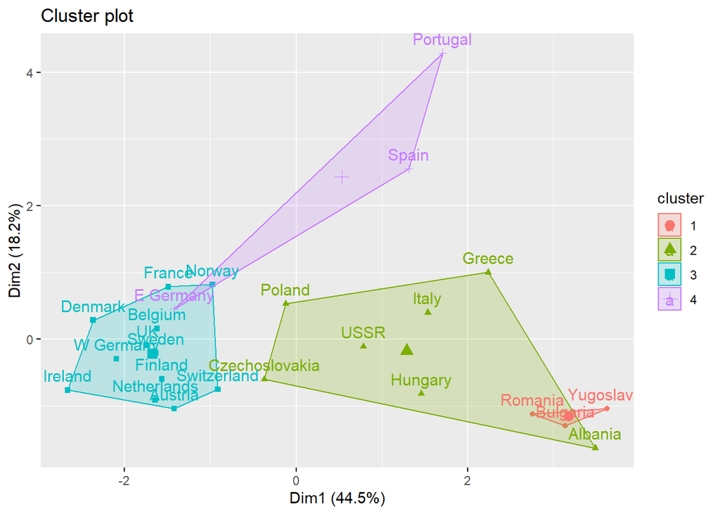

```r
k = 4; # my final answer?
X.kmeans = kmeans(X, k);
fviz_cluster(X.kmeans, data=X);
```

```r
# you may notice that it is changing cluster groups and boundaries at times ...
```

## 3.2 Computational efficiency: `kmeans` is better than `hclust`

K-means is a nice approach because it is computationally efficient. It is fast! We don’t notice the speed compared to `hclust` yet because the data sets are very small.

https://youtu.be/esmzYhuFnds?t=985 I would suggest watching from 16:25 to 23:30 … especially if you are CS-minded!

The problem with kmeans is the results may change based on the initial seeds. Here are two iterations I ran with the default algorithm. Do they look the same as yours?

## 3.3 K-means 3a and 3b

[figure not shown]

⇖ **K-means: 3a** ⇗

[figure not shown]

⇖ **K-means: 3b** ⇗

## 3.4 K-means 4a and 4b

[figure not shown]

⇖ **K-means: 4a** ⇗

[figure not shown]

⇖ **K-means: 4b** ⇗

## 3.5 Stopping rule: what is an ideal “k”?

The `wss` keeps going down as you can see in the appropriate plots. A general “rule of thumb” is called the elbow-rule of the Scree plot.

[figure not shown]

⇖ **K-means (wss): Hartigan-Wong** ⇗

[figure not shown]

⇖ **K-means (wss): Lloyd** ⇗

[figure not shown]

⇖ **K-means (wss): Forgy** ⇗

[figure not shown]

⇖ **K-means (wss): MacQueen** ⇗

Also think about what we did previously with `hclust` on this same data.

The library(factoextra) has `hkmeans` and `hcuts` that may work. I would always be cautious of a black-box solution, look at the graphics, and think about what you want to accomplish.

The `for loop` approach gives me the raw content, now I may want to review the image types side-by-side.

https://www.zevross.com/blog/2017/06/19/tips-and-tricks-for-working-with-images-and-figures-in-r-markdown-documents/

To aggregate by country, I am reviewing what is available to me, and am concluding that:

- Use the default algorithm
- For this data set, 3-4 appears to be is a nice choice for `k`
- I should define my centers to create `replicable` final results.
- I may try Poland, West Germany, Romania as my 3 centers (See Figure `K-means: 3b`).

## 3.6 K-means (final answer)

It is reasonable to pick 3 or 4 as your final answer. Review the information, and pick one that you can defend. A `4` gives you more variability but may not add much. You decide. Maybe you think `wss` clearly concludes `3`. Decision making and arriving at a definitive conclusion is an important part of data analytics. Just be able to defend your choice.

```r
protein$Country;
```

```
##  [1] "Albania"        "Austria"        "Belgium"        "Bulgaria"
##  [5] "Czechoslovakia" "Denmark"        "E Germany"      "Finland"
##  [9] "France"         "Greece"         "Hungary"        "Ireland"
## [13] "Italy"          "Netherlands"    "Norway"         "Poland"
## [17] "Portugal"       "Romania"        "Spain"          "Sweden"
## [21] "Switzerland"    "UK"             "USSR"           "W Germany"
## [25] "Yugoslavia"
```

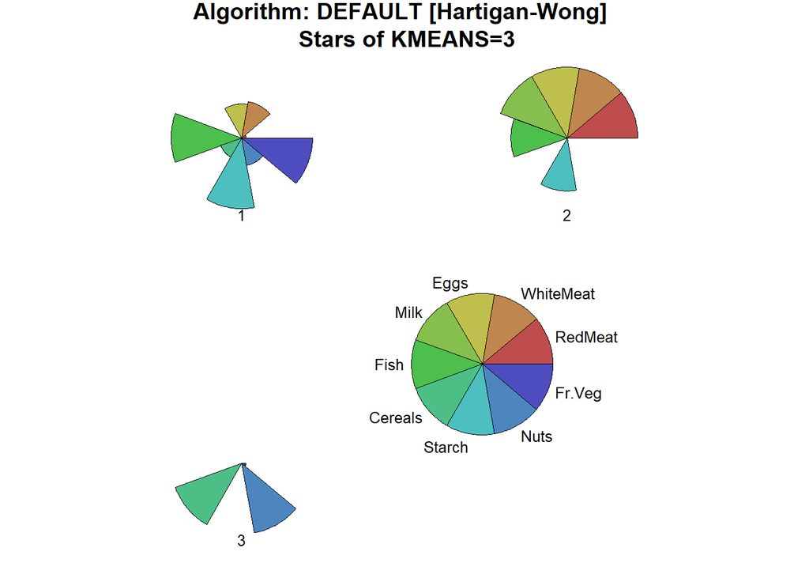

```r
# I could try and pass in the centers
# myCenters = matrix( c(X[16,], X[24,], X[18,]), nrow=3);  # This is not 2-D, or 3-D, but 9-D!
# Since we have 9-D, passing in nearest center Poland is not working ...
# X.kmeans = kmeans(X, myCenters);
# East Germany in 2-D (PCA transform) looks closer in distance to the "WEST"; however, in all 9-D it is closest in distance to its assigned cluster.


# this line needs to be changed ... 3 or 4 ?
myFinalAnswer = 3;  # 3 or 4, unless you want to defend 8 ...


X.kmeans = kmeans(X, myFinalAnswer, nstart=100);
# default algorithm, notice increase starts will do more "initial sampling" and find the best one (based on wss).  # I only have 25 countries, and I need to choise 3 ... 2300 would give me all options ? <https://www.calculatorsoup.com/calculators/discretemathematics/combinations.php>

# maybe move key.loc value to make graph look nice ...
stars(X.kmeans$centers, len = 0.5, key.loc = c(4, 3),
        main = paste0("Algorithm: DEFAULT [Hartigan-Wong] \n Stars of KMEANS=",myFinalAnswer), draw.segments = TRUE);
```

```r
print(X.kmeans);
```

```
## K-means clustering with 3 clusters of sizes 6, 12, 7
##
## Cluster means:
##     RedMeat WhiteMeat     Eggs     Milk     Fish  Cereals   Starch     Nuts
## 1  7.883333  7.566667 2.716667 11.68333 5.833333 31.33333 5.183333 3.133333
## 2 12.091667  9.441667 3.708333 23.00000 4.991667 24.02500 4.616667 1.766667
## 3  7.614286  5.528571 1.800000 11.67143 1.742857 47.12857 2.914286 5.257143
##     Fr.Veg
## 1 6.000000
## 2 3.491667
## 3 3.642857
##
## Clustering vector:
##        Albania        Austria        Belgium       Bulgaria Czechoslovakia
##              3              2              2              3              1
##        Denmark      E Germany        Finland         France         Greece
##              2              1              2              2              3
##        Hungary        Ireland          Italy    Netherlands         Norway
##              3              2              1              2              2
##         Poland       Portugal        Romania          Spain         Sweden
##              1              1              3              1              2
##    Switzerland             UK           USSR      W Germany     Yugoslavia
##              2              2              3              2              3
##
## Within cluster sum of squares by cluster:
## [1] 488.7267 656.4517 561.8714
##  (between_SS / total_SS =  67.4 %)
##
## Available components:
##
## [1] "cluster"      "centers"      "totss"        "withinss"     "tot.withinss"
## [6] "betweenss"    "size"         "iter"         "ifault"
```

```r
    membership = as.data.frame( matrix( X.kmeans$cluster, ncol=1)) ;

    rownames(membership) = protein$Country;

    membership;
```

|  | V1 |
| --- | --- |
| Albania | 3 |
| Austria | 2 |
| Belgium | 2 |
| Bulgaria | 3 |
| Czechoslovakia | 1 |
| Denmark | 2 |
| E Germany | 1 |
| Finland | 2 |
| France | 2 |
| Greece | 3 |

[output cut: 15 more lines]

```r
    print( table(membership) ) ;
```

```
## membership
##  1  2  3
##  6 12  7
```

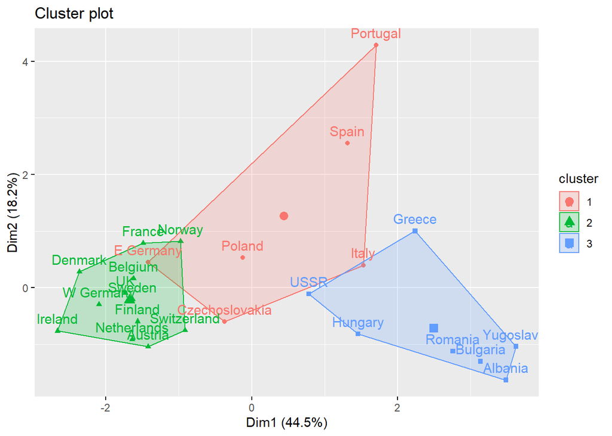

```r
fviz_cluster(X.kmeans,data=X);
```

```r
# will this be replicable? ...


library(devtools);
source_url("https://raw.githubusercontent.com/MonteShaffer/humanVerseWSU/master/humanVerseWSU/R/functions-EDA.R");

Xs = scale(X);
X.kmeans.info = perform.kmeans(Xs, 4);
```

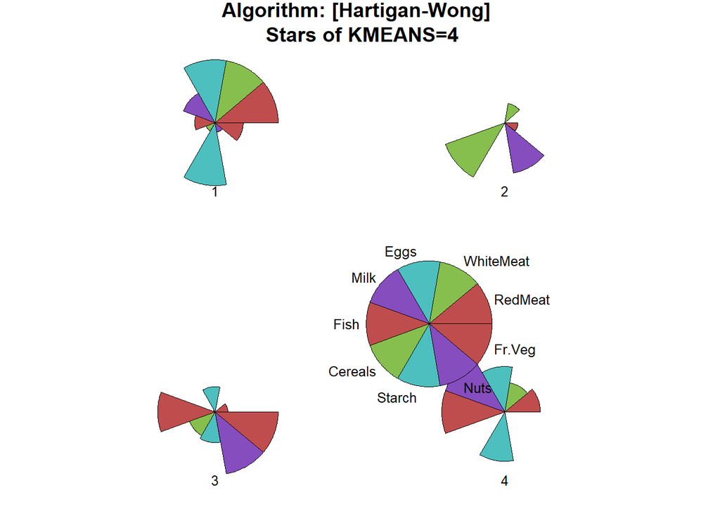

```r
str(X.kmeans.info);
```

```
## List of 3
##  $ kmeans    :List of 9
##   ..$ cluster     : Named int [1:25] 2 1 1 2 1 4 1 4 1 3 ...
##   .. ..- attr(*, "names")= chr [1:25] "Albania" "Austria" "Belgium" "Bulgaria" ...
##   ..$ centers     : num [1:4, 1:9] 0.61362 -0.79014 -0.5088 0.00657 0.77382 ...
##   .. ..- attr(*, "dimnames")=List of 2
##   .. .. ..$ : chr [1:4] "1" "2" "3" "4"
##   .. .. ..$ : chr [1:9] "RedMeat" "WhiteMeat" "Eggs" "Milk" ...
##   ..$ totss       : num 216
##   ..$ withinss    : num [1:4] 37.9 24.1 18.9 5.9
##   ..$ tot.withinss: num 86.8
##   ..$ betweenss   : num 129
##   ..$ size        : int [1:4] 11 6 4 4
##   ..$ iter        : int 2
##   ..$ ifault      : int 0
##   ..- attr(*, "class")= chr "kmeans"
##  $ membership:'data.frame':  25 obs. of  1 variable:
##   ..$ cluster: int [1:25] 2 1 1 2 1 4 1 4 1 3 ...
##  $ table     : 'table' int [1:4(1d)] 11 6 4 4
##   ..- attr(*, "dimnames")=List of 1
##   .. ..$ membership: chr [1:4] "1" "2" "3" "4"
```

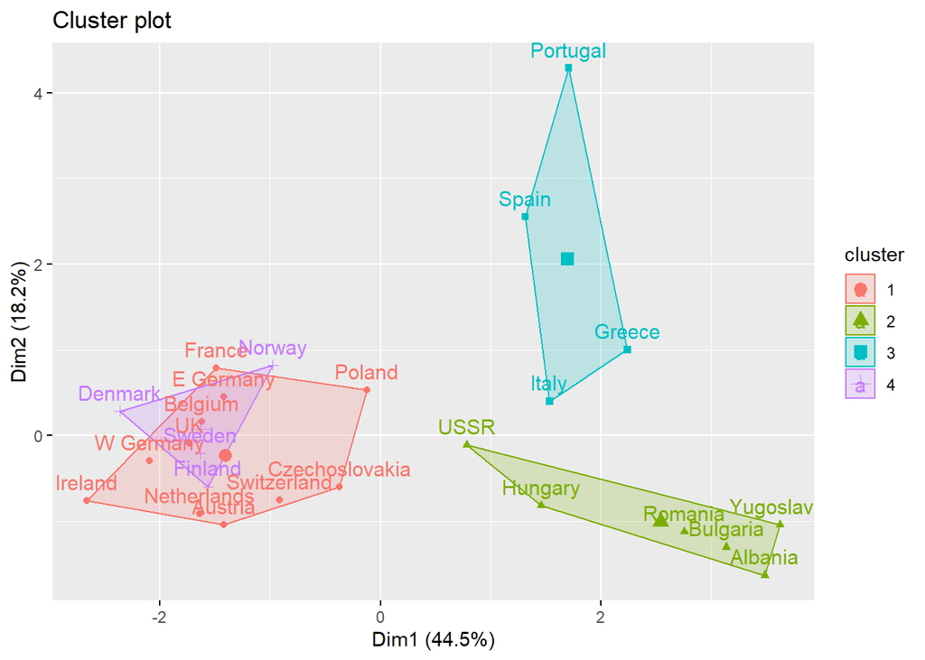

```r
factoextra::fviz_cluster(X.kmeans.info$kmeans, data=Xs);
```

# Synthesis (**S.T.A.R.S**)